# Capstone Quiz I

Complete all **Exercises**, and submit answers to **Questions** on the Coursera platform.

```r
setwd("C:/Home/Courses/Statistics with R")
library(ggplot2)
library(dplyr)
library(statsr)
```

This initial quiz will concern exploratory data analysis (EDA) of the Ames Housing dataset. EDA is essential when working with any source of data and helps inform modeling.

First, let us load the data:

```r
load("ames_train.Rdata")
```

1. Which of the following are the three variables with the highest number of missing observations? [B]
   1. `Misc.Feature`, `Fence`, `Pool.QC`
   2. `Misc.Feature`, `Alley`, `Pool.QC`
   3. `Pool.QC`, `Alley`, `Fence`
   4. `Fireplace.Qu`, `Pool.QC`, `Lot.Frontage`

```r
# type your code for Question 1 here, and Knit
sort(colSums(is.na(ames_train)), decreasing=T)
```

```
##         Pool.QC    Misc.Feature           Alley           Fence
##             997             971             933             798
##    Fireplace.Qu    Lot.Frontage   Garage.Yr.Blt     Garage.Qual
##             491             167              48              47
##     Garage.Cond     Garage.Type   Garage.Finish       Bsmt.Qual
##              47              46              46              21
##       Bsmt.Cond   Bsmt.Exposure  BsmtFin.Type.1  BsmtFin.Type.2
##              21              21              21              21
##    Mas.Vnr.Area    BsmtFin.SF.1    BsmtFin.SF.2     Bsmt.Unf.SF
##               7               1               1               1
##   Total.Bsmt.SF  Bsmt.Full.Bath  Bsmt.Half.Bath     Garage.Cars
##               1               1               1               1
##     Garage.Area             PID            area           price
##               1               0               0               0
##     MS.SubClass       MS.Zoning        Lot.Area          Street
##               0               0               0               0
##       Lot.Shape    Land.Contour       Utilities      Lot.Config
##               0               0               0               0
##      Land.Slope    Neighborhood     Condition.1     Condition.2
##               0               0               0               0
##       Bldg.Type     House.Style    Overall.Qual    Overall.Cond
##               0               0               0               0
##      Year.Built  Year.Remod.Add      Roof.Style       Roof.Matl
##               0               0               0               0
##    Exterior.1st    Exterior.2nd    Mas.Vnr.Type      Exter.Qual
##               0               0               0               0
##      Exter.Cond      Foundation         Heating      Heating.QC
##               0               0               0               0
##     Central.Air      Electrical     X1st.Flr.SF     X2nd.Flr.SF
##               0               0               0               0
## Low.Qual.Fin.SF       Full.Bath       Half.Bath   Bedroom.AbvGr
##               0               0               0               0
##   Kitchen.AbvGr    Kitchen.Qual   TotRms.AbvGrd      Functional
##               0               0               0               0
##      Fireplaces     Paved.Drive    Wood.Deck.SF   Open.Porch.SF
##               0               0               0               0
##  Enclosed.Porch     X3Ssn.Porch    Screen.Porch       Pool.Area
##               0               0               0               0
##        Misc.Val         Mo.Sold         Yr.Sold       Sale.Type
##               0               0               0               0
##  Sale.Condition
##               0
```

```r
# type your code for Question 2 here, and Knit
str(ames_train$MS.SubClass)
```

```
##  int [1:1000] 30 120 30 70 60 85 20 20 20 180 ...
```

```r
ames_train$MS.SubClass = as.factor(ames_train$MS.SubClass)
```

3. In terms of price, which neighborhood has the highest standard deviation? [A]
   1. `StoneBr`
   2. `Timber`
   3. `Veenker`
   4. `NridgHt`

```r
# type your code for Question 3 here, and Knit
ames_train %>%
  group_by(Neighborhood) %>%
  summarise(total=sd(price)) %>%
  arrange(-total)
```

```
## # A tibble: 27 × 2
##    Neighborhood     total
##          <fctr>     <dbl>
## 1       StoneBr 123459.10
## 2       NridgHt 105088.90
## 3        Timber  84029.57
## 4       Veenker  72545.41
## 5       Crawfor  71267.56
## 6       GrnHill  70710.68
## 7       Somerst  65199.49
## 8       Edwards  54851.63
## 9       CollgCr  52786.08
## 10      SawyerW  48354.36
## # ... with 17 more rows
```

4. Using scatter plots or other graphical displays, which of the following variables appears to be the best single predictor of `price`? [C]
   1. `Lot.Area`
   2. `Bedroom.AbvGr`
   3. `Overall.Qual`
   4. `Year.Built`

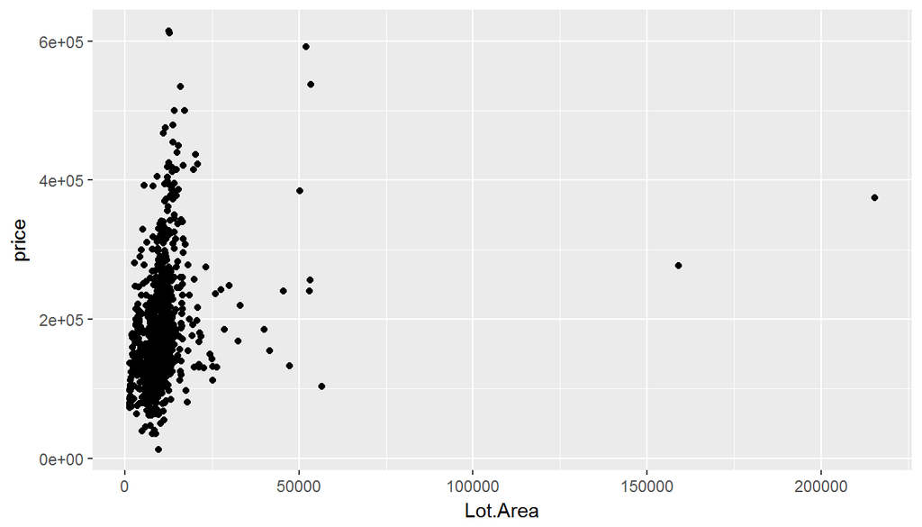

```r
# type your code for Question 4 here, and Knit
ggplot(ames_train, aes(Lot.Area, price)) + geom_point()
```

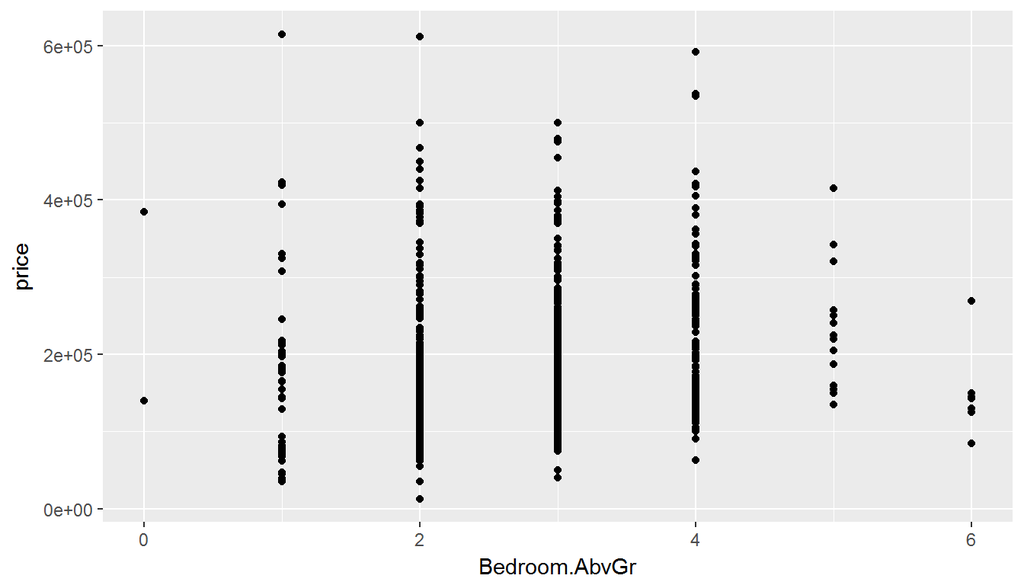

```r
ggplot(ames_train, aes(Bedroom.AbvGr, price)) + geom_point()
```

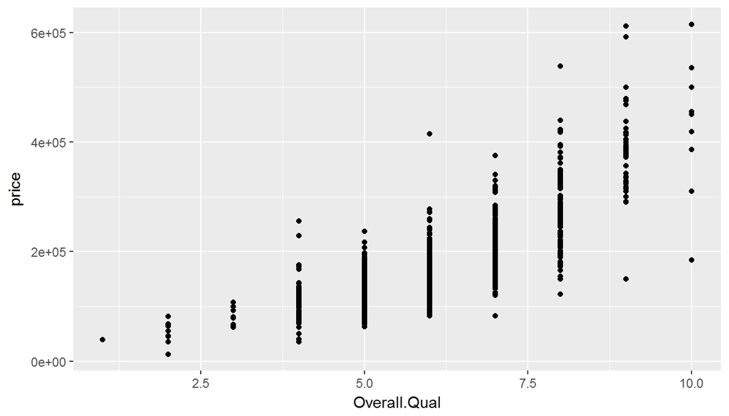

```r
ggplot(ames_train, aes(Overall.Qual, price)) + geom_point()
```

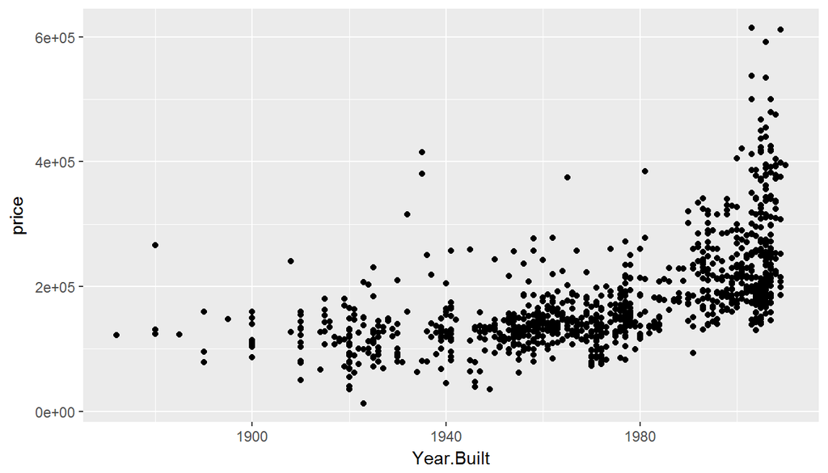

```r
ggplot(ames_train, aes(Year.Built, price)) + geom_point()
```

5. Suppose you are examining the relationship between `price` and `area`. Which of the following variable transformations makes the relationship appear to be the most linear? [D]
   1. Do not transform either `price` or `area`
   2. Log-transform `price` but not `area`
   3. Log-transform `area` but not `price`
   4. Log-transform both `price` and `area`

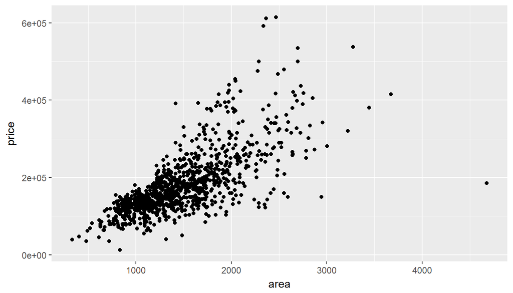

```r
# type your code for Question 5 here, and Knit
ggplot(ames_train, aes(area, price)) + geom_point()
```

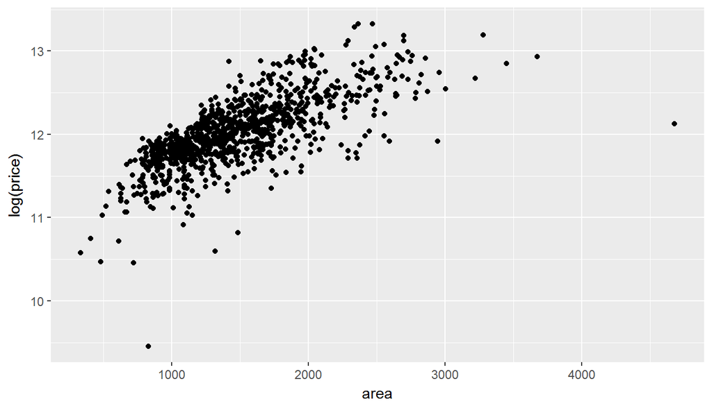

```r
ggplot(ames_train, aes(area, log(price))) + geom_point()
```

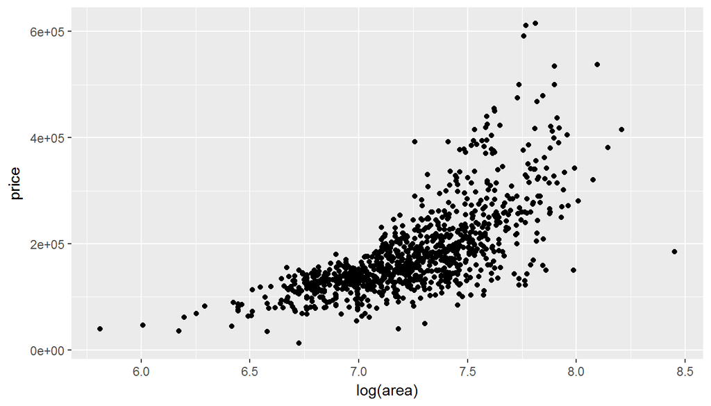

```r
ggplot(ames_train, aes(log(area), price)) + geom_point()
```

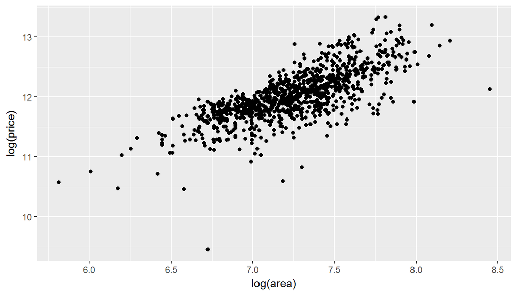

```r
ggplot(ames_train, aes(log(area), log(price))) + geom_point()
```

```r
# type your code for Question 6 here, and Knit
table(ames_train$Garage.Cars >= 1)
```

```
##
## FALSE  TRUE
##    46   953
```

7. Which of the following statements is true about the dataset? [C]
   1. Over 30 percent of houses were built after the year 1999.
   2. The median housing price is greater than the mean housing price.
   3. 21 houses do not have a basement.
   4. 4 houses are located on gravel streets.

```r
# type your code for Question 7 here, and Knit
table(ames_train$Year.Built > 1999)
```

```
##
## FALSE  TRUE
##   728   272
```

```r
median(ames_train$price) - mean(ames_train$price)
```

```
## [1] -21723.08
```

```r
table(ames_train$Total.Bsmt.SF > 0)
```

```
##
## FALSE  TRUE
##    21   978
```

```r
table(ames_train$Street)
```

```
##
## Grvl Pave
##    3  997
```

8. Test, at the $\alpha = 0.05$ level, whether homes with a garage have larger square footage than those without a garage. [A]
   1. With a p-value near 0.000, we reject the null hypothesis of no difference.
   2. With a p-value of approximately 0.032, we reject the null hypothesis of no difference.
   3. With a p-value of approximately 0.135, we fail to reject the null hypothesis of no difference.
   4. With a p-value of approximately 0.343, we fail to reject the null hypothesis of no difference.

```r
# type your code for Question 8 here, and Knit
with(ames_train, t.test(area[Garage.Cars>0], area[Garage.Cars==0]))
```

```
##
##  Welch Two Sample t-test
##
## data:  area[Garage.Cars > 0] and area[Garage.Cars == 0]
## t = 5.134, df = 50.702, p-value = 4.535e-06
## alternative hypothesis: true difference in means is not equal to 0
## 95 percent confidence interval:
##  211.4183 482.9963
## sample estimates:
## mean of x mean of y
##  1492.251  1145.043
```

9. For homes with square footage greater than 2000, assume that the number of bedrooms above ground follows a Poisson distribution with rate $\lambda$. Your prior on $\lambda$ follows a Gamma distribution with mean 3 and standard deviation 1. What is your posterior mean and standard deviation for the average number of bedrooms in houses with square footage greater than 2000 square feet?
   1. Mean: 3.61, SD: 0.11
   2. Mean: 3.62, SD: 0.16
   3. Mean: 3.63, SD: 0.09
   4. Mean: 3.63, SD: 0.91

```r
# type your code for Question 10 here, and Knit
# k * theta = mean
# sqrt(k) * theta = sd
# k = (mean / sd) ^ 2 = 9
# theta = mean / k = 1/3
k = 9
theta = 1/3
ames_q9 = ames_train[ames_train$area > 2000, ]
k_star = k + sum(ames_q9$Bedroom.AbvGr)
theta_star <- theta / (length(ames_q9$Bedroom.AbvGr) * theta + 1)
post_mean <- k_star * theta_star
post_sd <- theta_star * sqrt(k_star)
post_mean
```

```
## [1] 3.617021
```

```r
post_sd
```

```
## [1] 0.1601644
```

10. When regressing $\log$(`price`) on $\log$(`area`), there are some outliers. Which of the following do the three most outlying points have in common? [D]
    1. They had abnormal sale conditions.
    2. They have only two bedrooms.
    3. They have an overall quality of less than 3.
    4. They were built before 1930.

```r
# type your code for Question 10 here, and Knit
lm_q10 = lm(log(price) ~ log(area), ames_train)
res_q10 = resid(lm_q10) ** 2
threshold = sort(res_q10, partial=997)[997]
which(res_q10 > threshold)
```

```
## 206 428 741
## 206 428 741
```

```r
ames_train$Sale.Condition[c(206, 428, 741)]
```

```
## [1] Abnorml Abnorml Normal
## Levels: Abnorml AdjLand Alloca Family Normal Partial
```

```r
ames_train$Bedroom.AbvGr[c(206, 428, 741)]
```

```
## [1] 3 2 3
```

```r
ames_train$Overall.Qual[c(206, 428, 741)]
```

```
## [1] 4 2 4
```

```r
ames_train$Year.Built[c(206, 428, 741)]
```

```
## [1] 1910 1923 1920
```

11. Which of the following are reasons to log-transform `price` if used as a dependent variable in a linear regression?
    1. `price` is right-skewed.
    2. `price` cannot take on negative values.
    3. `price` can only take on integer values.
    4. Both a and b.

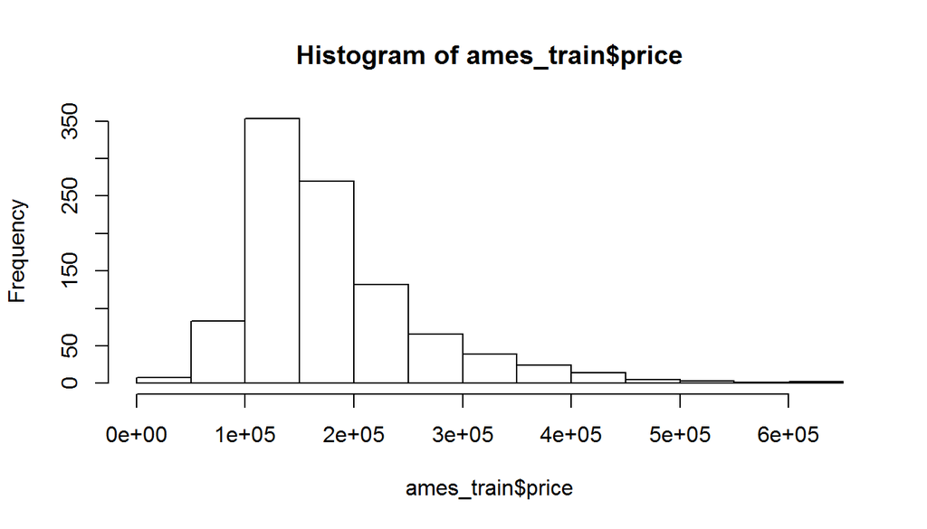

```r
# type your code for Question 11 here, and Knit
hist(ames_train$price)
```

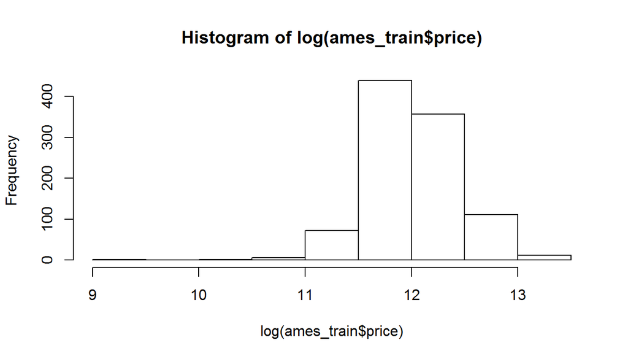

```r
hist(log(ames_train$price))
```

12. How many neighborhoods consist of only single-family homes? (e.g. `Bldg.Type` = `1Fam`) [D]
    1. 0
    2. 1
    3. 2
    4. 3

```r
# type your code for Question 12 here, and Knit
ames_train %>%
  group_by(Neighborhood) %>%
  summarise(flag=mean(Bldg.Type == '1Fam')) %>%
  arrange(-flag)
```

```
## # A tibble: 27 × 2
##    Neighborhood      flag
##          <fctr>     <dbl>
## 1       ClearCr 1.0000000
## 2       NoRidge 1.0000000
## 3        Timber 1.0000000
## 4       Gilbert 0.9795918
## 5       BrkSide 0.9756098
## 6        NWAmes 0.9756098
## 7       CollgCr 0.9647059
## 8        IDOTRR 0.9428571
## 9         NAmes 0.9225806
## 10       Sawyer 0.9180328
## # ... with 17 more rows
```

13. Using color, different plotting symbols, conditioning plots, etc., does there appear to be an association between $\log$(`area`) and the number of bedrooms above ground (`Bedroom.AbvGr`)? [A]
    1. Yes
    2. No

```r
# type your code for Question 13 here, and Knit
cor(ames_train$Bedroom.AbvGr, log(ames_train$area))
```

```
## [1] 0.5457625
```

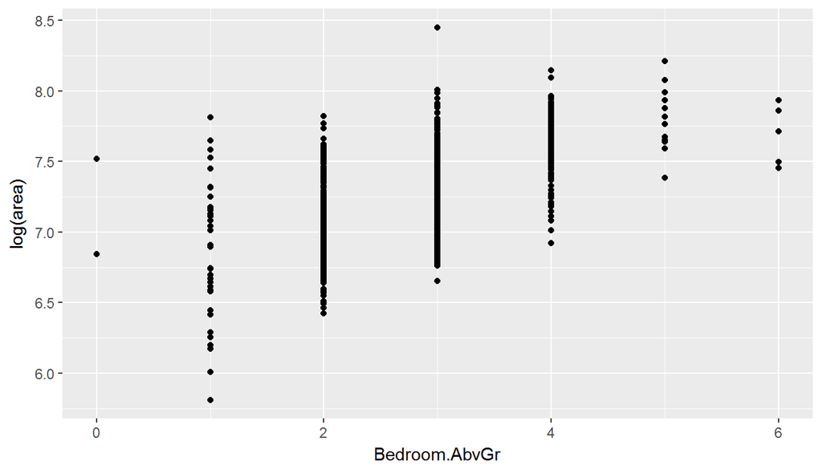

```r
ggplot(ames_train, aes(Bedroom.AbvGr, log(area))) + geom_point()
```

14. Of the people who have unfinished basements, what is the average square footage of the unfinished basement? [B]
    1. 590.36
    2. 595.27
    3. 614.37
    4. 681.94

```r
# type your code for Question 14 here, and Knit
ames_train %>%
  filter(Bsmt.Unf.SF > 0) %>%
  summarise(mean(Bsmt.Unf.SF))
```

```
## # A tibble: 1 × 1
##   `mean(Bsmt.Unf.SF)`
##                 <dbl>
## 1            595.2527
```